# Practical Machine Learning Project - Wearable Computing

### 3.2 Preprocessing data

In this step, we will re-create *training* with the 75% of cases and create a new dataset called *validating* with the remaining 25% of cases.

```r
# Sets seed
set.seed(21)

# Slices the training data
inTrain <- createDataPartition(y = training$classe, p = 0.75, list = FALSE)

# Creates a cross-validation set
validating <- training[-inTrain, ]
dim(validating)
```

```
## [1] 4904   53
```

```r
# Recreates the training set, removing observations of validating set.
training <- training[inTrain, ]
dim(training)
```

```
## [1] 14718    53
```

```r
# Shows datasets heads
head(training[, c(1:5, 53)])
```

```
##   roll_belt pitch_belt yaw_belt total_accel_belt gyros_belt_x classe
## 2      1.41       8.07    -94.4                3         0.02      A
## 3      1.42       8.07    -94.4                3         0.00      A
## 4      1.48       8.05    -94.4                3         0.02      A
## 5      1.48       8.07    -94.4                3         0.02      A
## 7      1.42       8.09    -94.4                3         0.02      A
## 9      1.43       8.16    -94.4                3         0.02      A
```

```r
head(validating[, c(1:5, 53)])
```

```
##    roll_belt pitch_belt yaw_belt total_accel_belt gyros_belt_x classe
## 1       1.41       8.07    -94.4                3         0.00      A
## 6       1.45       8.06    -94.4                3         0.02      A
## 8       1.42       8.13    -94.4                3         0.02      A
## 14      1.42       8.21    -94.4                3         0.02      A
## 20      1.59       8.07    -94.4                3         0.02      A
## 23      1.56       8.10    -94.3                3         0.02      A
```

```r
head(testing[, 1:5])
```

```
##   roll_belt pitch_belt yaw_belt total_accel_belt gyros_belt_x
## 1    123.00      27.00    -4.75               20        -0.50
## 2      1.02       4.87   -88.90                4        -0.06
## 3      0.87       1.82   -88.50                5         0.05
## 4    125.00     -41.60   162.00               17         0.11
## 5      1.35       3.33   -88.60                3         0.03
## 6     -5.92       1.59   -87.70                4         0.10
```

Now the datasets are ready for the next step: data modeling.

### 3.2 Preprocessing data

```r
# Sets seed
set.seed(13173)

# Normalizes data
pre.proc <- preProcess(training[, -53], method = c("center", "scale"))
training <- predict(pre.proc, training)
testing <- predict(pre.proc, testing)

# Slices the training data
in.train <- createDataPartition(y = training$classe, p = 0.7, list = FALSE)

# Creates a cross-validation set
validating <- training[-in.train, ]
dim(validating)
```

```
## [1] 5885   53
```

```r
# Recreates the training set, removing observations of validating set
training <- training[in.train, ]
dim(training)
```

```
## [1] 13737    53
```

```r
# Shows datasets heads
head(training[, c(1:5, 53)])
```

```
##   roll_belt pitch_belt   yaw_belt total_accel_belt gyros_belt_x classe
## 1 -1.003935  0.3473953 -0.8739522         -1.07366   0.02697255      A
## 2 -1.003935  0.3473953 -0.8739522         -1.07366   0.12343758      A
## 4 -1.002820  0.3465005 -0.8739522         -1.07366   0.12343758      A
## 5 -1.002820  0.3473953 -0.8739522         -1.07366   0.12343758      A
## 6 -1.003298  0.3469479 -0.8739522         -1.07366   0.12343758      A
## 9 -1.003617  0.3514220 -0.8739522         -1.07366   0.12343758      A
```

```r
head(validating[, c(1:5, 53)])
```

```
##    roll_belt pitch_belt   yaw_belt total_accel_belt gyros_belt_x classe
## 3  -1.003776  0.3473953 -0.8739522         -1.07366   0.02697255      A
## 7  -1.003776  0.3482901 -0.8739522         -1.07366   0.12343758      A
## 8  -1.003776  0.3500797 -0.8739522         -1.07366   0.12343758      A
## 10 -1.003298  0.3518694 -0.8739522         -1.07366   0.17167009      A
## 15 -1.003298  0.3532116 -0.8739522         -1.07366   0.02697255      A
## 16 -1.002820  0.3509745 -0.8739522         -1.07366   0.02697255      A
```

```r
head(testing[, 1:5])
```

```
##    roll_belt  pitch_belt    yaw_belt total_accel_belt gyros_belt_x
## 1  0.9337461  1.19432812  0.06780959        1.1220673   -2.3846531
## 2 -1.0101504  0.20422655 -0.81617538       -0.9444997   -0.2624225
## 3 -1.0125408  0.06776881 -0.81197343       -0.8153392    0.2681351
## 4  0.9656184 -1.87485252  1.81949698        0.7345860    0.5575302
## 5 -1.0048915  0.13532658 -0.81302392       -1.0736601    0.1716701
## 6 -1.1207476  0.05747856 -0.80356953       -0.9444997    0.5092977
```

## 4. Data Modeling

We will use *Random Forest* algorithm to predict the outcomes of *classe* variable.

```r
modelRF <- randomForest(classe ~ ., data = training)
predictValidating <- predict(modelRF, validating, type = "class")
cfMatrix <- confusionMatrix(predictValidating, validating$classe)
print(cfMatrix)
```

[output not shown]

The confusion matrix above shows that the accuracy of our model is 99.61%.  
The figure below shows the error versus number of trees:

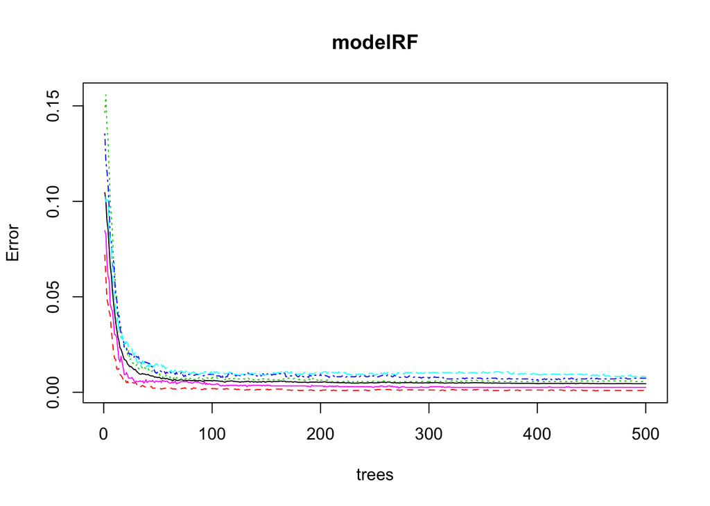

```r
plot(modelRF)
```

## 5. Predictions

Finally, we will make predictions about the outcome of *classe* variable, using the *testing* dataset.

```r
predictTesting <- predict(modelRF, testing, type = "class")
print(predictTesting)
```

```
##  1  2  3  4  5  6  7  8  9 10 11 12 13 14 15 16 17 18 19 20
##  B  A  B  A  A  E  D  B  A  A  B  C  B  A  E  E  A  B  B  B
## Levels: A B C D E
```